# Frameworks to Arrange UI Elements

## Frameworks

Organizes UI elements.

Allows sensible grouping of elements.

## Some high-level frameworks

- `fluidPage()` –
- `fixedPage()` – just rows and columns
- `fullPage()` – fills up the browser window
- `tagList()` – just sequential
- `navbarPage()` – use with `tabPanel()` and `navbarMenu()`
- `miniUI::miniUI()` – for add-ins or mobile
- `runtime::shiny` in an Rmd file – for reports

## `fluidPage()`

An organization using the [Bootstrap](https://getbootstrap.com/docs/4.4/) CSS/JavaScript/HTML system.

Define containers based on a 12-unit wide grid.

## Return to Project 1

We’re now going to throw away the original UI for Project 1.

- Look at `Muggle.R`. What kind of thing is `First`, `Second`, and so on in terms of user interfaces.
- Modify `app.R` file to source the UI defined in `UI-languages.R`.
- Notice that the highest level container in `UI-languages.R` is `tagList()`.
  - What do you expect to happen when–don’t do it yet!– you replace `tagList()` with `fluidPage()`? Talk to your neighbor about what you expect to put a stake in the ground.
  - Now do the replacement.
  - What changes in the display of the app? Is this what you expected? If not, speculate on what’s wrong?

## Need to use the grid system!

Nothing much was different between `fluidPage()` and `tagList()` in the previous exercise:

1. Usual all-in-a-line layout.
2. Fonts are different.

In order to get things laid out, we need to specify rows and columns for the 12-unit Bootstrap grid.

Use `fluidRow(...)` to group elements in a row.

Use `column(width=..., ...)` to group elements in a column of the indicated width.

## Your turn

Edit `UI-languages.R` to change the UI to this.

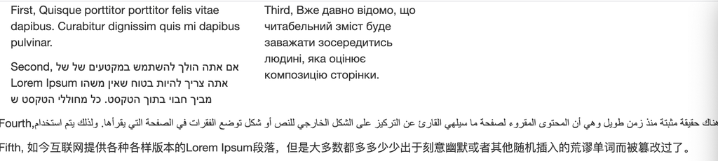

## The tree

```r
UI <- fluidPage(
  fluidRow(
    column(width  = 4, First, Second),
    column(width = 3, Third)
  ),
  fluidRow(Fourth, Fifth),
  title = "Fluid!"
)
```

Your turn: Draw this as a tree with `First`, `Second` as the leaves and UI layout statements as the nodes. Hint: The root is at `fluidPage()`.

What’s up with `title = "Fluid!"`?

## fluidPage() is responsive

The layout depends on the width of the device.

Narrow window

Wide window

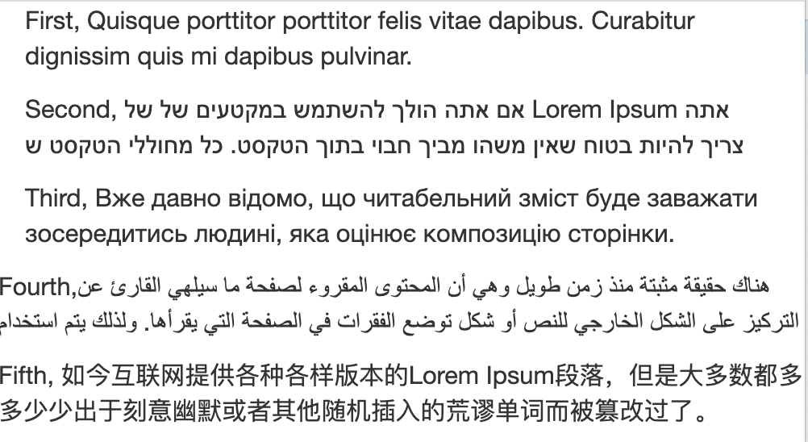

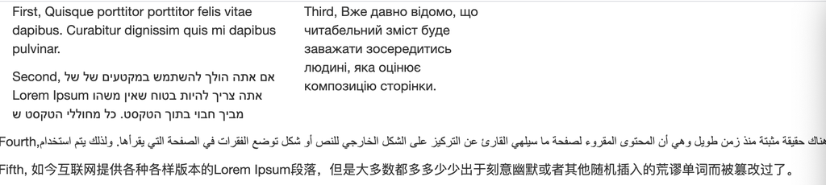

## Your turn: A new tree

Draw this interface as a tree. Remember, the nodes are UI layout functions (like `column()`) and the leaves are `First`, `Second` and so on.

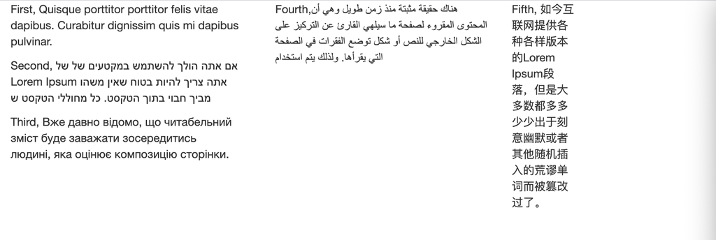

Modify `UI-languages.R` to implement this tree.

## Answer:

```r
UI <- fluidPage(
  fluidRow(
    column(width  = 4, First, Second, Third),
    column(width = 6,
      column(width=8, Fourth),
      column(width=3, Fifth)
    )
  )
)
```

## Your turn: Another tree

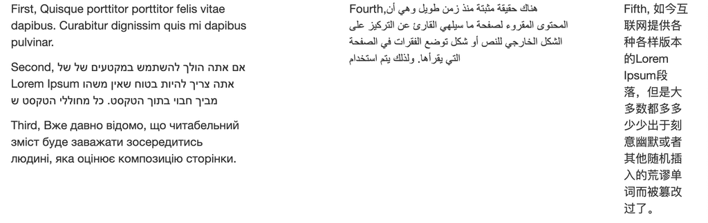

Implement this UI. You’ll need to use both the `width` and `offset` arguments to `column()`.

## Answer:

```r
UI <- fluidPage(
  fluidRow(
    column(width  = 4, First, Second, Third),
    column(width = 6, offset = 1,
      column(width=8,Fourth),
      column(width=3, offset=1, Fifth)
    )
  )
)
```

## Convenience UI layout functions

- `titlePanel()`
- `sidebarLayout()` with `sidebarPanel()` & `mainPanel()`
- `tabsetPanel()` and `tabPanel()`
- `splitLayout()`
- `flowLayout()`
- `verticalLayout()`
- `wellPanel()`

## Your turn: Make this

Use `fluidPage()`, `titlePanel()`, and `wellPanel()`

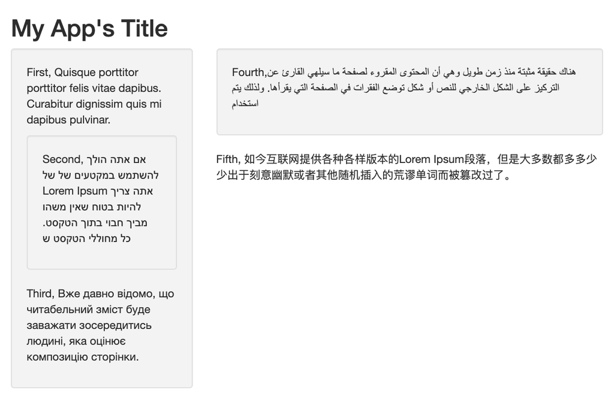

## The tree

```r
UI <-
  fluidPage(
    titlePanel("My App's Title"),
    fluidRow(
      column(width = 4,
        wellPanel(
          First,
          wellPanel(
            Second),
          Third)),
      column(width = 8,
        wellPanel(
          Fourth),
        Fifth)
  )
)
```